Loading libraries

##Anscombe’s quartet This data set illustrates how variables even with identical numerical statistical properties when plotted are very different, proving the necessity of also plotting data.

```r
df <- anscombe
colnames(df)
```

```
## [1] "x1" "x2" "x3" "x4" "y1" "y2" "y3" "y4"
```

```r
df_combined <- rbind(data.frame(x=df$x1, y=df$y1, set="1"),
                     data.frame(x=df$x2, y=df$y2, set="2"),
                     data.frame(x=df$x3, y=df$y3, set="3"),
                     data.frame(x=df$x4, y=df$y4, set="4"))
#groups columns into pairs so that they can be facceted, set column is a factor
```

Scatter plot facceted by set

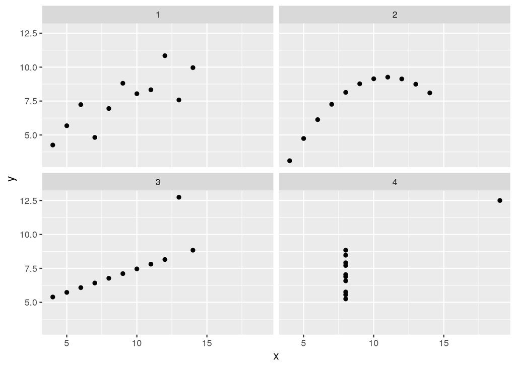

```r
df_combined %>% ggplot(aes(x, y)) + geom_point() + facet_wrap(~set)
```

Means and standard deviations by set

```r
df_combined %>%
  group_by(set) %>%
  summarise(mean_x = mean(x), mean_y = mean(y), sd_x = sd(x), sd_y = sd(y))
```

```
## # A tibble: 4 x 5
##   set   mean_x mean_y  sd_x  sd_y
##   <fct>  <dbl>  <dbl> <dbl> <dbl>
## 1 1          9   7.50  3.32  2.03
## 2 2          9   7.50  3.32  2.03
## 3 3          9   7.5   3.32  2.03
## 4 4          9   7.50  3.32  2.03
```

Pearsons, Kendalls and Spearmans test results by set and their respective p-values

```r
df_combined %>%
  group_by(set) %>%
  summarise(Pearson = cor(x,y, method = "pearson"), pValue_Pearson = cor.test(x,y, method = "pearson")$p.value,
            Kendall = cor(x,y, method = "kendall"), pValue_Kendall = cor.test(x,y, method = "kendall")$p.value,
            Spearman = cor(x,y, method = "spearman"), pValue_Spearman = cor.test(x,y, method = "spearman")$p.value,
            )
```

```
## # A tibble: 4 x 7
##   set   Pearson pValue_Pearson Kendall pValue_Kendall Spearman pValue_Spearman
##   <fct>   <dbl>          <dbl>   <dbl>          <dbl>    <dbl>           <dbl>
## 1 1       0.816        0.00217   0.636    0.00571        0.818         0.00373
## 2 2       0.816        0.00218   0.564    0.0165         0.691         0.0231
## 3 3       0.816        0.00218   0.964    0.000000551    0.991         0
## 4 4       0.817        0.00216   0.426    0.114          0.5           0.117
```

Added geom smooth with method lm

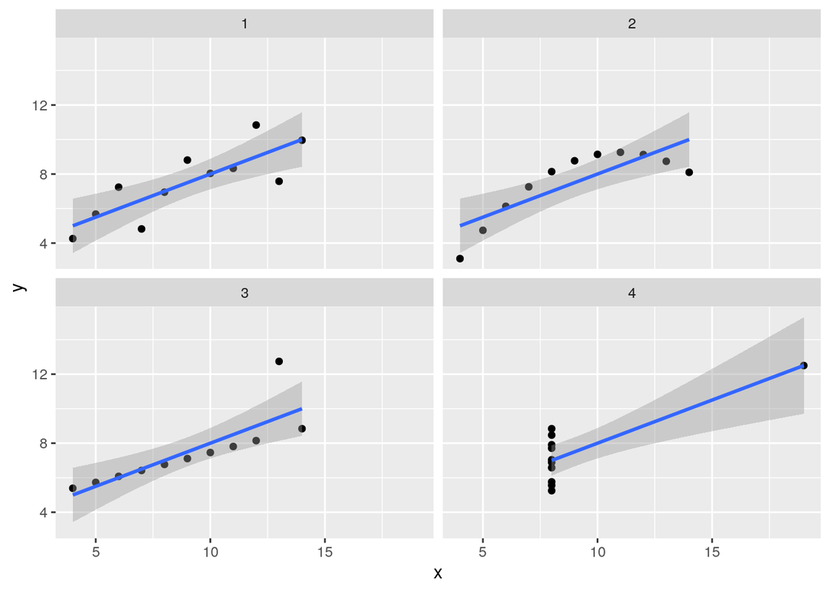

```r
df_combined %>% ggplot(aes(x, y)) + geom_point() + facet_wrap(~set) + geom_smooth(method = lm)
```

##Air quality data set Data Set Information:

The dataset contains 9358 instances of hourly averaged responses from an array of 5 metal oxide chemical sensors embedded in an Air Quality Chemical Multisensor Device. The device was located on the field in a significantly polluted area, at road level,within an Italian city. Data were recorded from March 2004 to February 2005 (one year)representing the longest freely available recordings of on field deployed air quality chemical sensor devices responses. Ground Truth hourly averaged concentrations for CO, Non Metanic Hydrocarbons, Benzene, Total Nitrogen Oxides (NOx) and Nitrogen Dioxide (NO2) and were provided by a co-located reference certified analyzer. Evidences of cross-sensitivities as well as both concept and sensor drifts are present as described in De Vito et al., Sens. And Act. B, Vol. 129,2,2008 (citation required) eventually affecting sensors concentration estimation capabilities. Missing values are tagged with -200 value. This dataset can be used exclusively for research purposes. Commercial purposes are fully excluded.

Attribute Information:

0 Date (DD/MM/YYYY) 1 Time (HH.MM.SS) 2 True hourly averaged concentration CO in mg/m^3 (reference analyzer) 3 PT08.S1 (tin oxide) hourly averaged sensor response (nominally CO targeted) 4 True hourly averaged overall Non Metanic HydroCarbons concentration in microg/m^3 (reference analyzer) 5 True hourly averaged Benzene concentration in microg/m^3 (reference analyzer) 6 PT08.S2 (titania) hourly averaged sensor response (nominally NMHC targeted) 7 True hourly averaged NOx concentration in ppb (reference analyzer) 8 PT08.S3 (tungsten oxide) hourly averaged sensor response (nominally NOx targeted) 9 True hourly averaged NO2 concentration in microg/m^3 (reference analyzer) 10 PT08.S4 (tungsten oxide) hourly averaged sensor response (nominally NO2 targeted) 11 PT08.S5 (indium oxide) hourly averaged sensor response (nominally O3 targeted) 12 Temperature in Â°C 13 Relative Humidity (%) 14 AH Absolute Humidity

Loading csv file

```r
AQ_raw <- read.csv("/home/aleksandar/Desktop/R statistics 2/hw_1_Rstat2/AirQualityUCI/AirQualityUCI.csv", sep = ";")
```

Removing NAs Since missing values are denoted with -200 in this data set, first step would be to change all -200 values to NA and then remove NAs

```r
AQ_NAs <- AQ_raw %>% na_if(-200) %>% na_if("-200,0")
#removing empty columns
toDrop <- c("X", "X.1")
AQ_NAs <- AQ_NAs[,!(names(AQ_NAs)) %in% toDrop]
```

Exploring NAs, after visually checking data set it seems most NAs are from NMHC.GT column

```r
sapply(AQ_NAs, function(x) sum(is.na(x)))
```

```
##          Date          Time        CO.GT.   PT08.S1.CO.      NMHC.GT.
##             0             0          1683           480          8557
##      C6H6.GT. PT08.S2.NMHC.       NOx.GT.  PT08.S3.NOx.       NO2.GT.
##           366           480          1753           480          1756
##  PT08.S4.NO2.   PT08.S5.O3.             T            RH            AH
##           480           480           366           366           366
```

Since NMHC.GT has a lot of NAs using complete cases would drop about 90% of cases. I think its a good option to remove NMHC.GT from the main analyses.

```r
toDrop <- c("NMHC.GT.", "Date", "Time") #also dropped Date and Time colums since I wont be using them
AQ_NAs <- AQ_NAs[,!(names(AQ_NAs)) %in% toDrop]
complete_AQrows <- complete.cases(AQ_NAs)
AQ <- AQ_NAs[complete_AQrows,]
```

Checking for non numeric variables

```r
sapply(AQ, function(x)is.numeric(x))
```

```
##        CO.GT.   PT08.S1.CO.      C6H6.GT. PT08.S2.NMHC.       NOx.GT.
##         FALSE          TRUE         FALSE          TRUE          TRUE
##  PT08.S3.NOx.       NO2.GT.  PT08.S4.NO2.   PT08.S5.O3.             T
##          TRUE          TRUE          TRUE          TRUE         FALSE
##            RH            AH
##         FALSE         FALSE
```

```r
AQnum <- data.frame(sapply(AQ, function(x) as.double(gsub(",",".",x)))) #converting to double

sapply(AQnum, function(x)is.numeric(x))
```

```
##        CO.GT.   PT08.S1.CO.      C6H6.GT. PT08.S2.NMHC.       NOx.GT.
##          TRUE          TRUE          TRUE          TRUE          TRUE
##  PT08.S3.NOx.       NO2.GT.  PT08.S4.NO2.   PT08.S5.O3.             T
##          TRUE          TRUE          TRUE          TRUE          TRUE
##            RH            AH
##          TRUE          TRUE
```

Exploring the data individually

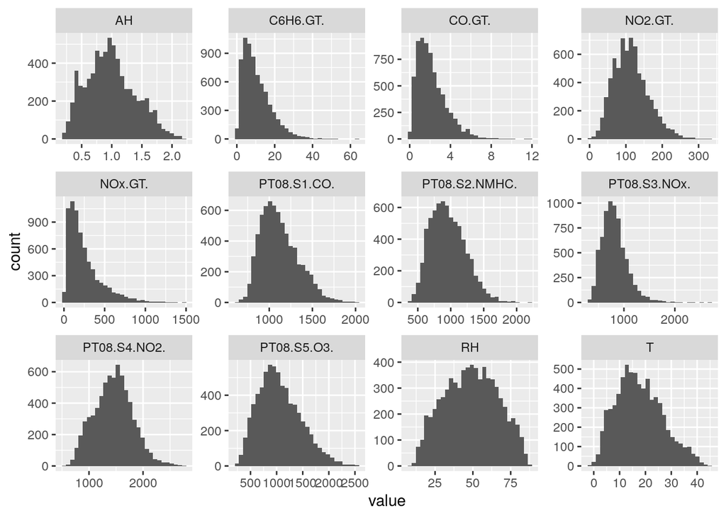

```r
AQlong <- gather(AQnum)

ggplot(AQlong, aes(value)) + geom_histogram() + facet_wrap(~key, scales = "free")
```

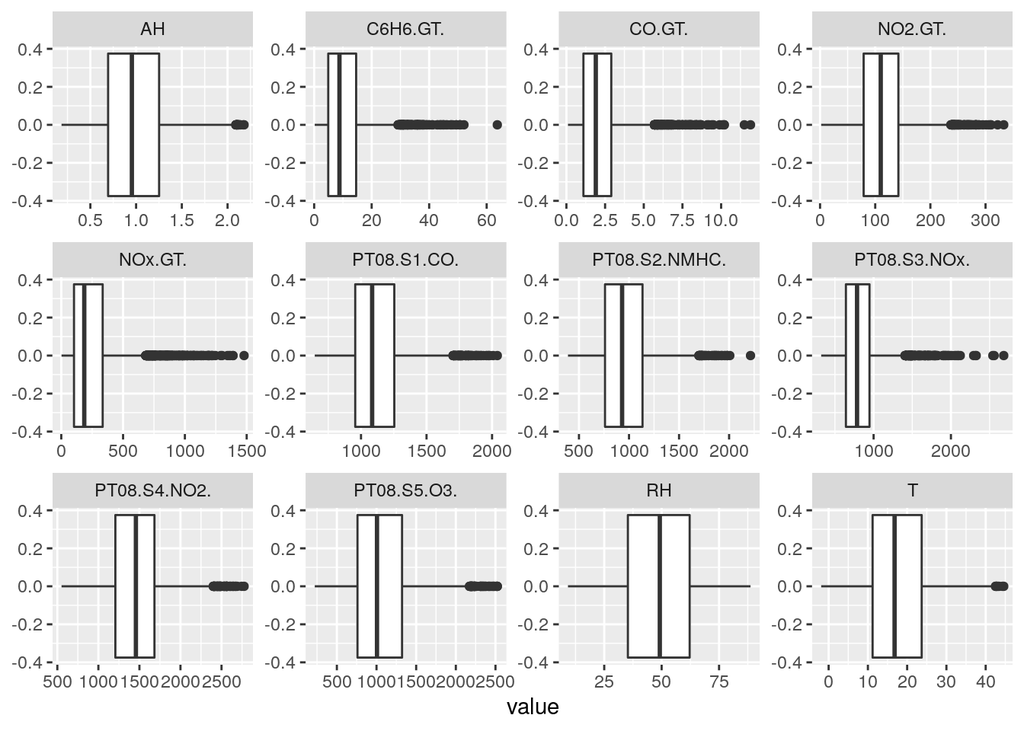

```r
ggplot(AQlong, aes(value)) + geom_boxplot() + facet_wrap(~key, scales = "free")
```

Finding pairwise correlations for data set Response for further analyses is C6H6.GT.

```r
sapply(AQnum, function(x) sapply(AQnum, function(y) cor(x,y)))
```

```
##                    CO.GT. PT08.S1.CO.    C6H6.GT. PT08.S2.NMHC.    NOx.GT.
## CO.GT.         1.00000000  0.87701378  0.93000844    0.91431022  0.7864556
## PT08.S1.CO.    0.87701378  1.00000000  0.87743017    0.88606831  0.7077047
## C6H6.GT.       0.93000844  0.87743017  1.00000000    0.98270456  0.7183438
## PT08.S2.NMHC.  0.91431022  0.88606831  0.98270456    1.00000000  0.7053592
## NOx.GT.        0.78645556  0.70770473  0.71834383    0.70535922  1.0000000
## PT08.S3.NOx.  -0.70103781 -0.76289451 -0.72572179   -0.78163029 -0.6621663
## NO2.GT.        0.67383957  0.62826276  0.60324096    0.63330954  0.7570291
## PT08.S4.NO2.   0.63083404  0.67590960  0.76180525    0.77428754  0.2337926
## PT08.S5.O3.    0.85348004  0.89716636  0.86115359    0.87677728  0.7885502
## T              0.01833425  0.02827677  0.18900256    0.22833308 -0.2759984
## RH             0.06475315  0.16923408 -0.02159153   -0.04608374  0.2322552
## AH             0.05934617  0.14975239  0.18707157    0.20559028 -0.1441860
##               PT08.S3.NOx.    NO2.GT. PT08.S4.NO2. PT08.S5.O3.           T
## CO.GT.         -0.70103781  0.6738396  0.630834042  0.85348004  0.01833425
## PT08.S1.CO.    -0.76289451  0.6282628  0.675909601  0.89716636  0.02827677
## C6H6.GT.       -0.72572179  0.6032410  0.761805247  0.86115359  0.18900256
## PT08.S2.NMHC.  -0.78163029  0.6333095  0.774287538  0.87677728  0.22833308
## NOx.GT.        -0.66216631  0.7570291  0.233792602  0.78855025 -0.27599835
## PT08.S3.NOx.    1.00000000 -0.6413769 -0.511223442 -0.79336411 -0.09949483
## NO2.GT.        -0.64137694  1.0000000  0.142612010  0.70252411 -0.21432470
## PT08.S4.NO2.   -0.51122344  0.1426120  1.000000000  0.57424200  0.56658556
## PT08.S5.O3.    -0.79336411  0.7025241  0.574242002  1.00000000 -0.04614601
## T              -0.09949483 -0.2143247  0.566585555 -0.04614601  1.00000000
## RH             -0.11647947 -0.0753329 -0.009160077  0.16482121 -0.56390892
## AH             -0.22338099 -0.3496460  0.646390126  0.07580693  0.66063806
##                         RH          AH
## CO.GT.         0.064753147  0.05934617
## PT08.S1.CO.    0.169234080  0.14975239
## C6H6.GT.      -0.021591530  0.18707157
## PT08.S2.NMHC. -0.046083742  0.20559028
## NOx.GT.        0.232255190 -0.14418603
## PT08.S3.NOx.  -0.116479467 -0.22338099
## NO2.GT.       -0.075332896 -0.34964601
## PT08.S4.NO2.  -0.009160077  0.64639013
## PT08.S5.O3.    0.164821208  0.07580693
## T             -0.563908917  0.66063806
## RH             1.000000000  0.17957592
## AH             0.179575919  1.00000000
```

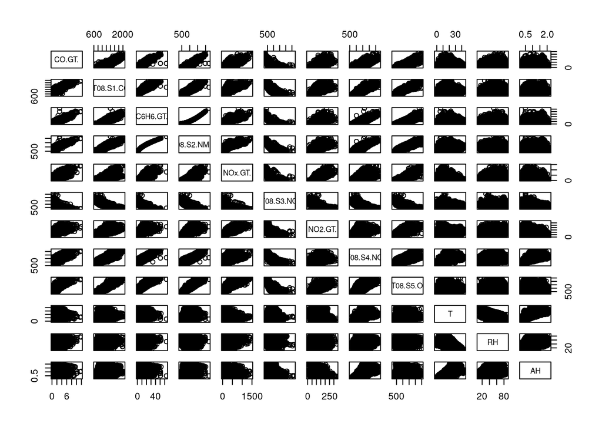

```r
pairs(AQnum, )
```

##Visualising and inspecting some pairs of columns more closely

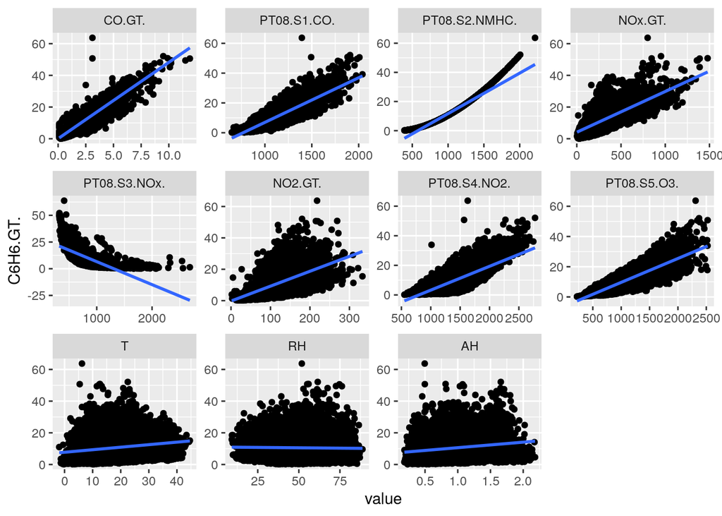

```r
d <- melt(AQnum, id.vars = "C6H6.GT.")
ggplot(d, aes(x = value, y = C6H6.GT.)) + geom_point() + geom_smooth(method = lm) + facet_wrap(~variable, scales = "free")
```

All models with response C6H6

```r
depVarList = setdiff(colnames(AQnum), c("C6H6.GT."))

allModels = lapply(depVarList, function(x){
  lm(formula= paste0("C6H6.GT. ~ `", x, "`"), data= AQnum)})

names(allModels) = depVarList
print(lapply(allModels, function(x) summary(x)))
```

```
## $CO.GT.
##
## Call:
## lm(formula = paste0("C6H6.GT. ~ `", x, "`"), data = AQnum)
##
## Residuals:
##     Min      1Q  Median      3Q     Max
## -15.198  -1.585  -0.158   1.497  48.725
##
## Coefficients:
##             Estimate Std. Error t value Pr(>|t|)
## (Intercept)  0.04054    0.05977   0.678    0.498
## CO.GT.       4.81746    0.02286 210.782   <2e-16 ***
## ---
## Signif. codes:  0 '***' 0.001 '**' 0.01 '*' 0.05 '.' 0.1 ' ' 1
##
## Residual standard error: 2.744 on 6939 degrees of freedom
## Multiple R-squared:  0.8649, Adjusted R-squared:  0.8649
## F-statistic: 4.443e+04 on 1 and 6939 DF,  p-value: < 2.2e-16
##
##
## $PT08.S1.CO.
##
## Call:
## lm(formula = paste0("C6H6.GT. ~ `", x, "`"), data = AQnum)
##
## Residuals:
##     Min      1Q  Median      3Q     Max
## -11.955  -2.260  -0.183   1.955  44.938
##
## Coefficients:
##               Estimate Std. Error t value Pr(>|t|)
## (Intercept) -2.298e+01  2.243e-01  -102.5   <2e-16 ***
## PT08.S1.CO.  2.995e-02  1.965e-04   152.4   <2e-16 ***
## ---
## Signif. codes:  0 '***' 0.001 '**' 0.01 '*' 0.05 '.' 0.1 ' ' 1
##
## Residual standard error: 3.581 on 6939 degrees of freedom
## Multiple R-squared:  0.7699, Adjusted R-squared:  0.7699
## F-statistic: 2.322e+04 on 1 and 6939 DF,  p-value: < 2.2e-16
```

[output cut: 174 more lines]

```
##
## Residuals:
##     Min      1Q  Median      3Q     Max
## -12.451  -5.553  -1.702   3.861  54.853
##
## Coefficients:
##             Estimate Std. Error t value Pr(>|t|)
## (Intercept)   7.1229     0.2335   30.50   <2e-16 ***
## AH            3.4818     0.2195   15.86   <2e-16 ***
## ---
## Signif. codes:  0 '***' 0.001 '**' 0.01 '*' 0.05 '.' 0.1 ' ' 1
##
## Residual standard error: 7.334 on 6939 degrees of freedom
## Multiple R-squared:  0.035,  Adjusted R-squared:  0.03486
## F-statistic: 251.6 on 1 and 6939 DF,  p-value: < 2.2e-16
```

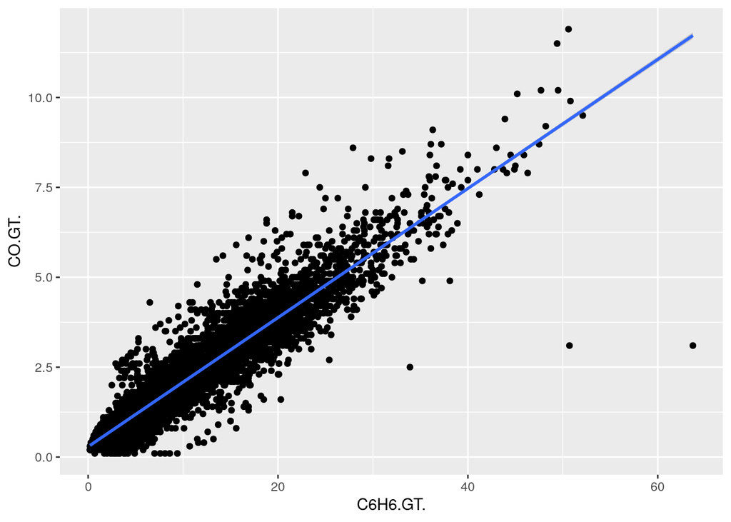

```r
ggplot(AQnum, aes( C6H6.GT., CO.GT.) ) + geom_point() + geom_smooth(method = lm)
```

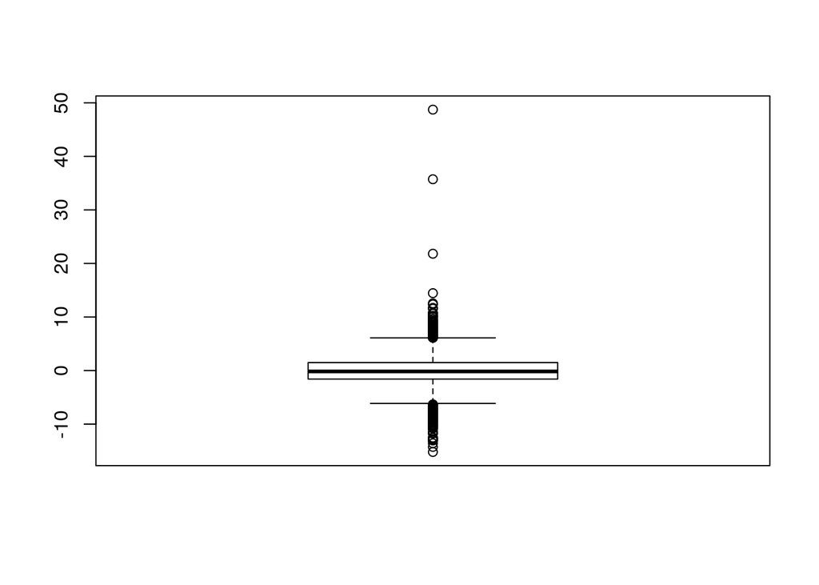

```r
modCO <-lm(formula = C6H6.GT. ~ CO.GT., data = AQnum)
boxplot(modCO$residuals)
```

Residuals vs fitted - how well do fitted value align to residuals - it means residuals are euqally spread around the data

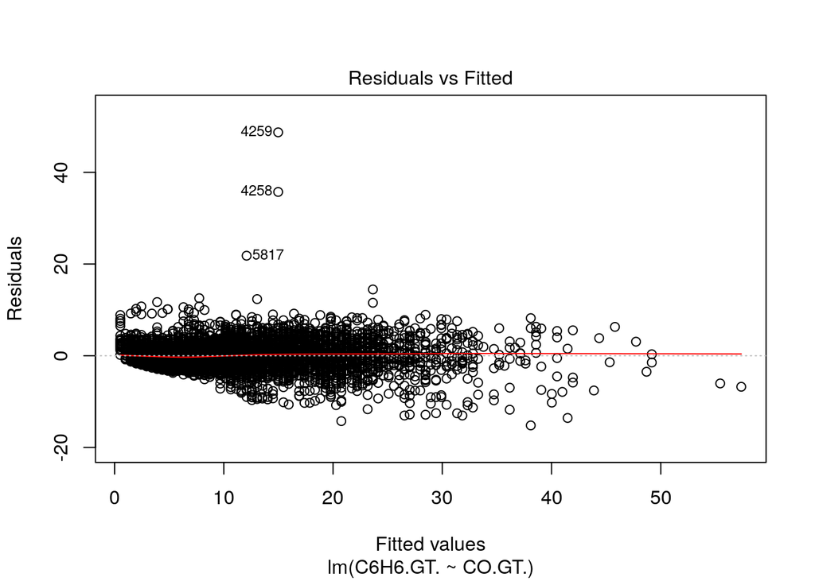

```r
plot(modCO, which = 1)
```

QQplot - are theoretical quantiles the same as actual ones - if they are on the line distribution is close to normal

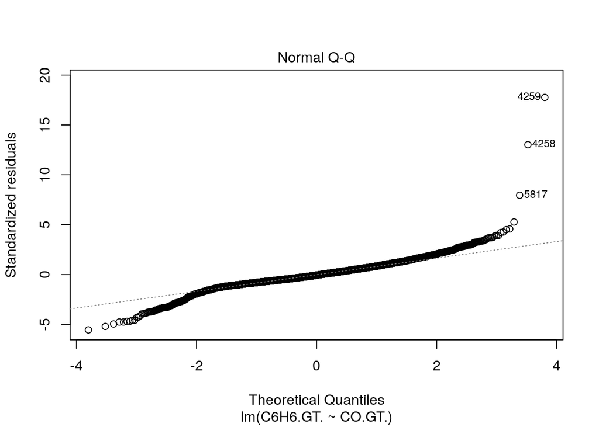

```r
plot(modCO, which = 2)
```

Perfoming train vs test data LM analysis

```r
set.seed(42)
sample <- sample.int(n = nrow(AQnum), size = floor(0.75 * nrow(AQnum)))
train <- AQnum[sample,]
test <- AQnum[-sample,]

new_modCO <- lm(data = train, formula = C6H6.GT. ~ CO.GT.)
summary(new_modCO)
```

```
##
## Call:
## lm(formula = C6H6.GT. ~ CO.GT., data = train)
##
## Residuals:
##     Min      1Q  Median      3Q     Max
## -14.194  -1.592  -0.178   1.505  35.758
##
## Coefficients:
##             Estimate Std. Error t value Pr(>|t|)
## (Intercept)  0.08072    0.06845   1.179    0.238
## CO.GT.       4.79383    0.02625 182.621   <2e-16 ***
## ---
## Signif. codes:  0 '***' 0.001 '**' 0.01 '*' 0.05 '.' 0.1 ' ' 1
##
## Residual standard error: 2.722 on 5203 degrees of freedom
## Multiple R-squared:  0.865,  Adjusted R-squared:  0.865
## F-statistic: 3.335e+04 on 1 and 5203 DF,  p-value: < 2.2e-16
```

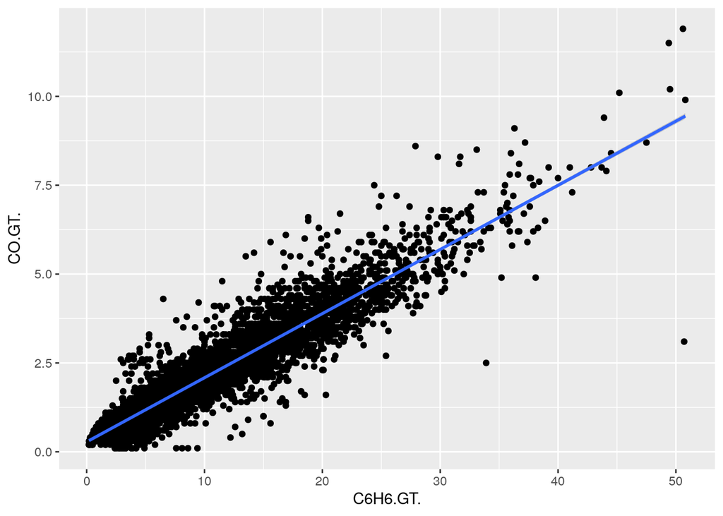

```r
ggplot(data = train,aes( C6H6.GT., CO.GT.) ) + geom_point() + geom_smooth(method = lm)
```

Prediction using trained model

```r
pred <- predict(new_modCO, newdata = test)
test$CO.GT._predicted <- pred
```

Constructing plot

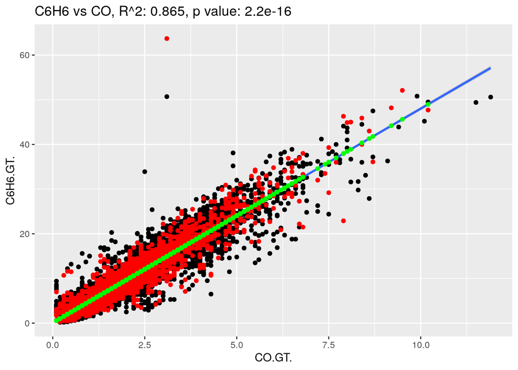

```r
ggplot() + geom_point(data = train, aes(x= CO.GT., y = C6H6.GT.)) + geom_smooth(data =train, aes(x=CO.GT., C6H6.GT.),method = lm) + geom_point(data = test,  colour = "red", aes(x= CO.GT., y = C6H6.GT.)) + geom_point(data = test,  colour = "green", aes(x= CO.GT. ,y = CO.GT._predicted)) + ggtitle("C6H6 vs CO, R^2: 0.865, p value: 2.2e-16")
```